# 1. Introduction

Alexandr Byzov

07 09 2020

# Preface

This instruction manual belongs to the course ‘Nonreactive and Big Data in Social Sciences’ which is a part of Complex Social Analysis Master program of NRU HSE.

# Introduction

## RStudio

“RStudio is an integrated development environment (IDE) for R. It includes a console, syntax-highlighting editor that supports direct code execution, as well as tools for plotting, history, debugging and workspace management” [Learn more about RStudio](https://rstudio.com/products/rstudio/features/).

### [Creating a comfortable layout in RStudio](https://www.r-bloggers.com/a-perfect-rstudio-layout/)

1. Go to “Tools”;
2. Here click on “Global Options”;
3. Choose “Pane Layout”;
4. Click on the top right menu with “Environment…” and change it to “Console”
5. Tick “Environment” in the bottom right square
6. Click on “Ok”
7. Minimize your bottom left window in R

Your layout should like this one

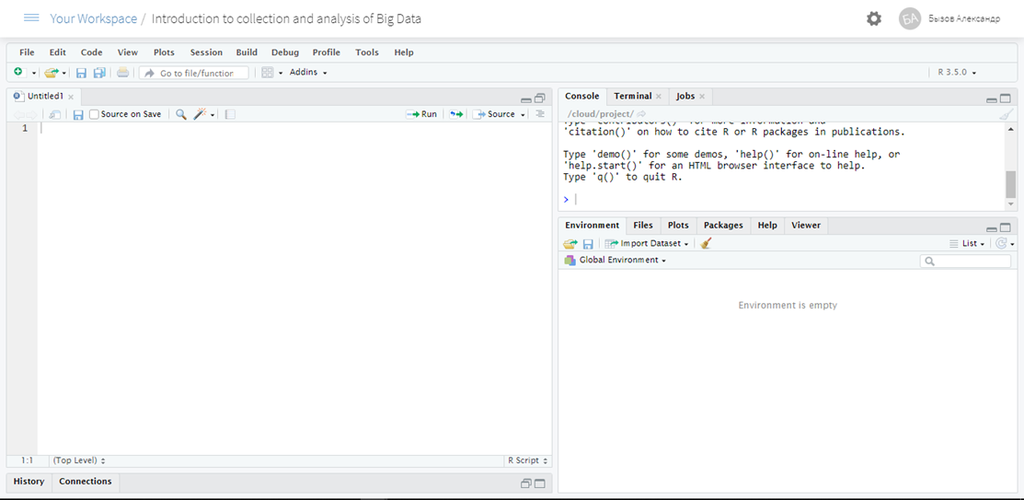

- Scripts are written on the left window;
- Top right window is for code progression and results
- Variables, models, data, files, graphs, and help could be seen on the right bottom window

### [Creating projects](https://support.rstudio.com/hc/en-us/articles/200526207-Using-Projects)

1. Go to “File”;
2. Here click on “New Project”;
3. Choose “New Directory”;
4. In the following menu choose “New project”;
5. In this menu choose a folder where you will keep your projects and write down title of the project directory;
6. Click on “Create project”.

Projects are important for numerous reason [see](https://r4ds.had.co.nz/workflow-projects.html), but one of the key features is that you could easily access files that are in project folder with R without writing absolute path to the file (i.e. insted of C://Users/Alex/Folder/Folder/More Folders/Even More folders/My project/Data/data.csv you could just write Data/data.csv)

### Creating and saving scripts

First, create an R script *File > New File > R Script* and save it with *Ctrl+S*. This script will automatically suggest a project folder. Save it under the title ‘Script’.

## Commentaries and sections

During this course we will use two types of comments:

1. Section, which is created with Ctrl+Shift+R;
2. Line comment, which is created with # or Ctrl+Shift+C